# Solutions to Problems in (Re)doing Bayesian Data Analysis

R Pruim

## Chapter 2

1. Consider Figure 2.6 on page 29 of *DBDA2E*. Two of the data points fall above the vertical bars. Does this mean that the model does not describe the data well? Briefly explain your answer.

No. The model suggests that roughly 5% of the data should fall outside the range of these bars. That looks compatible with the data we have.

Note: These points are *not* outliers – they fit the pattern that the model anticipates for the data (at least as far as this plot diagnoses) just fine. The model says there should be some data out there.

### Some General comments on problems 2-6

In problems 2-6, the point was to draw conclusions from a comparison of the pictures presented. 2. Run the following examples in R. Compare the plots produced and comment the big idea(s) illustrated by this comparison.

[output not shown]

The posterior can only be non-zero if both of the following are true:

- the prior is non-zero
- the data are possible (ie, the likelihood is not zero)

In each example we see that flipping a head drops the posterior to 0 for a coin that only gives tails because it is impossible to flip a head with such a coin. The last example shows that if the prior is 0, the posterior will also be 0. If our prior says something is impossible, no amount of data will change our minds. (So generally, we are cautious about having the prior be 0 unless something is truly impossible, not just unlikely or unexpected.)

3. Run the following examples in R. Compare the plots produced and comment the big idea(s) illustrated by this comparison.

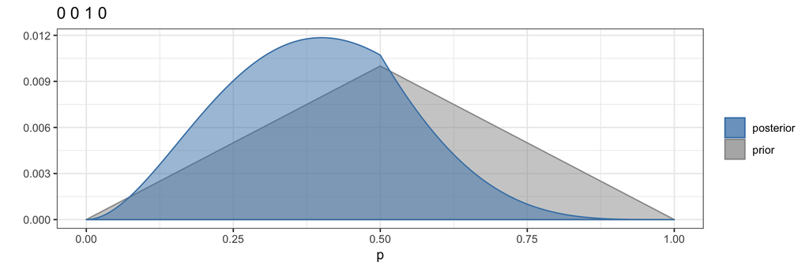

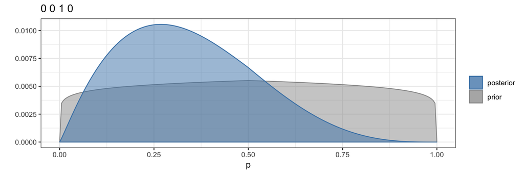

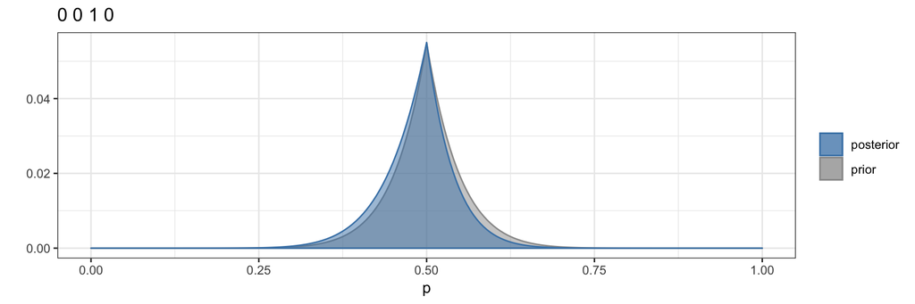

   ```r
   library(CalvinBayes)
   BernGrid("TTHT", prior = triangle::dtriangle)
   BernGrid("TTHT",
            prior = function(x) triangle::dtriangle(x)^0.1)
   BernGrid("TTHT",
            prior = function(x) triangle::dtriangle(x)^10)
   ```

The only thing changing in these examples is the prior, the data are the same each time. The more concentrated the prior, the more it shapes the posterior.

4. Run the following examples in R. Compare the plots produced and comment the big idea(s) illustrated by this comparison.

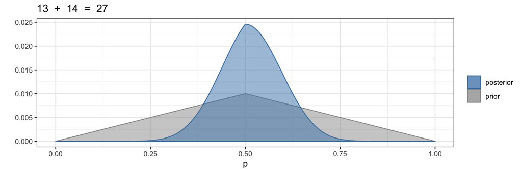

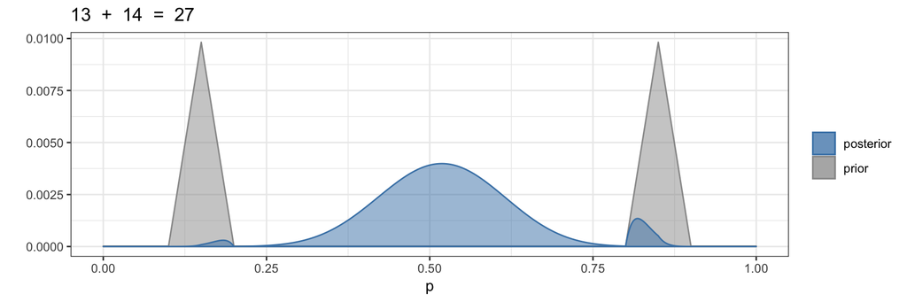

   ```r
   library(CalvinBayes)
   dfoo <- function(p) {
     0.02 * dunif(p) +
     0.49 * triangle::dtriangle(p, 0.1, 0.2) +
     0.49 * triangle::dtriangle(p, 0.8, 0.9)
   }
   BernGrid(c(rep(0,13), rep(1,14)), prior = triangle::dtriangle)
   BernGrid(c(rep(0,13), rep(1,14)), resolution = 1000, prior = dfoo)
   ```

Comparing the two priors we see that the large concentrations of the foo prior near 0.15 and 0.85 result in a posterior that allocates some credibility there even though the data are suggesting a value near 0.5. Since the triangle distribution does not assign especially large credibility there, those “bumps” near 0.15 and 0.85 are not present in the posterior when we use a triangle prior.

Also note that the posterior bumps for the foo prior are shifted toward the center (because the data are near 50% heads).

5. Run the following examples in R. Compare the plots produced and comment the big idea(s) illustrated by this comparison.

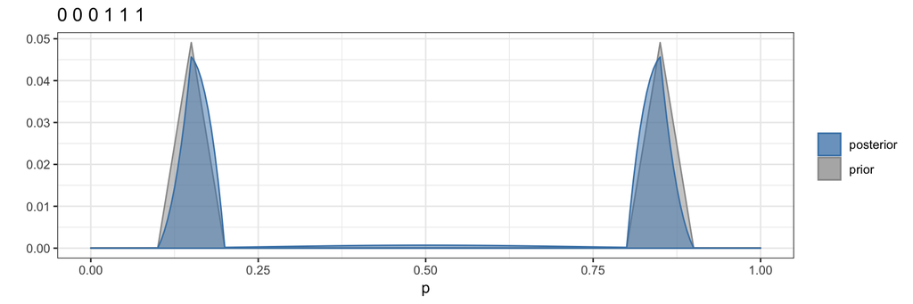

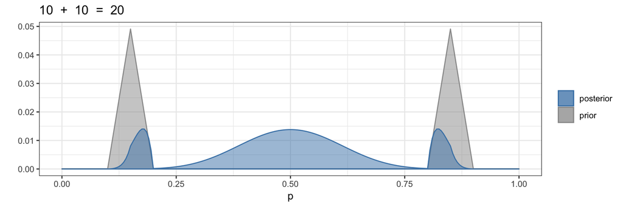

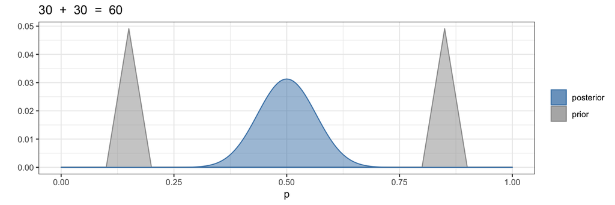

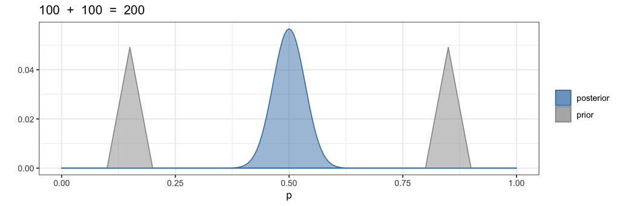

   ```r
   library(CalvinBayes)
   dfoo <- function(p) {
     0.02 * dunif(p) +
     0.49 * triangle::dtriangle(p, 0.1, 0.2) +
     0.49 * triangle::dtriangle(p, 0.8, 0.9)
   }
   BernGrid(c(rep(0, 3), rep(1, 3)), prior = dfoo)
   BernGrid(c(rep(0, 10), rep(1, 10)),  prior = dfoo)
   BernGrid(c(rep(0, 30), rep(1, 30)),  prior = dfoo)
   BernGrid(c(rep(0, 100), rep(1, 100)), prior = dfoo)
   ```

With little data, the prior has great sway over the posterior. With more and more data, the influence of the prior becomes less and less.

6. Run the following examples in R and compare them to the ones in the previous exercise. What do you observe?

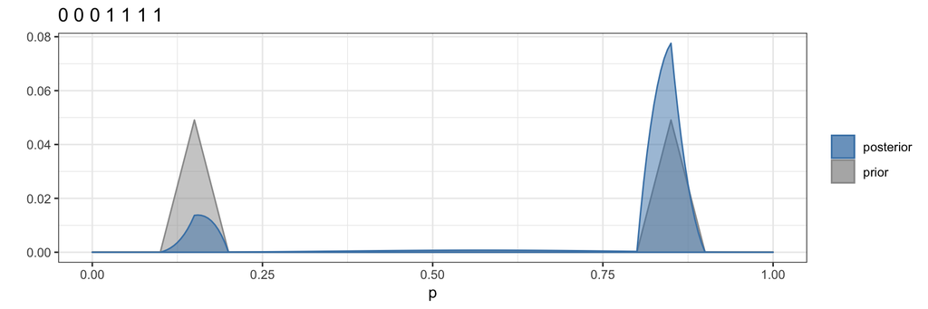

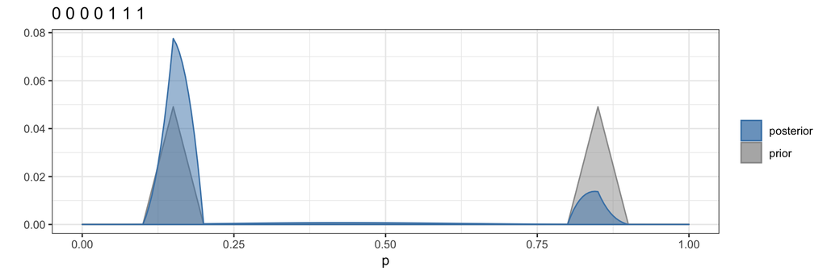

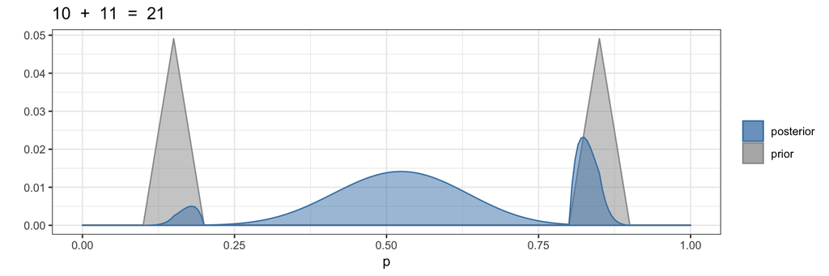

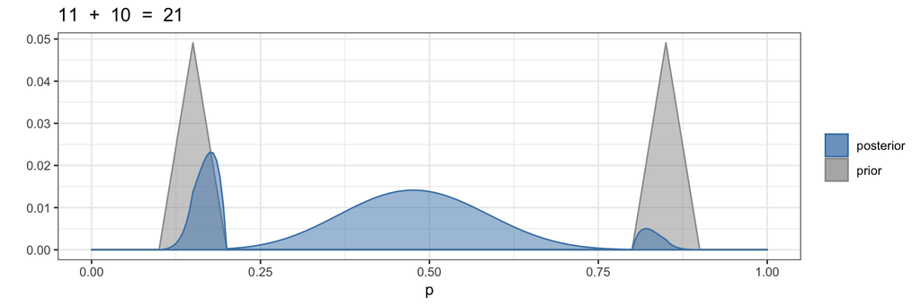

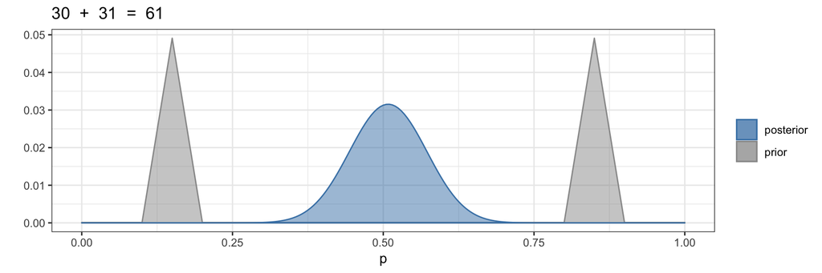

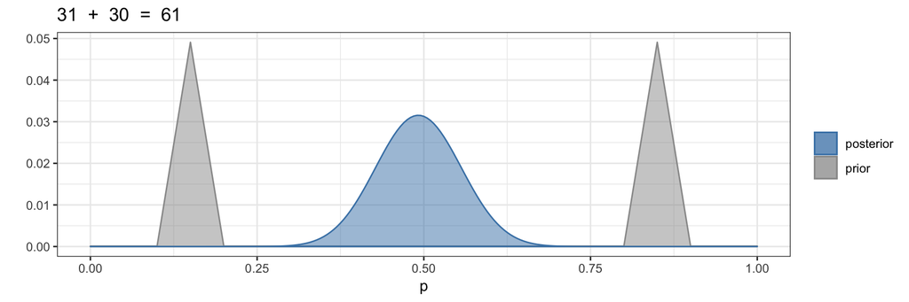

   ```r
   library(CalvinBayes)
   dfoo <- function(p) {
     0.02 * dunif(p) +
     0.49 * triangle::dtriangle(p, 0.1, 0.2) +
     0.49 * triangle::dtriangle(p, 0.8, 0.9)
   }
   BernGrid(c(rep(0, 3), rep(1, 4)), prior = dfoo)
   BernGrid(c(rep(0, 4), rep(1, 3)), prior = dfoo)
   BernGrid(c(rep(0, 10), rep(1, 11)),  prior = dfoo)
   BernGrid(c(rep(0, 11), rep(1, 10)),  prior = dfoo)
   BernGrid(c(rep(0, 30), rep(1, 31)),  prior = dfoo)
   BernGrid(c(rep(0, 31), rep(1, 30)),  prior = dfoo)
   ```

A very informative/opinionated prior can turn small differences in a small data set into large differences in the posterior because it pushes the posterior toward one of the regions where the prior is large. But with more and more data, this effect becomes less and less pronounced.

## Chapter 3

1. Create a function in R that converts Fahrenheit temperatures to Celsius temperatures. [Hint: $C = (F-32) \cdot 5/9$.]

   What you turn in should show
   1. the code that defines your function.
   2. some test cases that show that your function is working. (Show that -40, 32, 98.6, and 212 convert to -40, 0, 37, and 100.) Note: you should be able to test all these cases by calling the function only once. Use `c(-40, 32, 98.6, 212)` as the input.

```r
to_celsius <- function(temp) {
  (temp - 32) * 5 / 9
}
to_celsius(c(-40, 32, 98.6, 212))
```

```
## [1] -40   0  37 100
```

## Chapter 4

1. Suppose a random variable has the pdf $p(x) = 6x (1-x)$ on the interval $[0,1]$. (That means it is 0 outside of that interval.)
   1. Use `function()` to create a function in R that is equivalent to `p(x)`.
   2. Use `gf_function()` to plot the function on the interval $[0, 1]$.
   3. Integrate by hand to show that the total area under the pdf is 1 (as it should be for any pdf).
   4. Now have R compute that same integral (using `integrate()`).
   5. What is the largest value of $p(x)$? At what value of $x$ does it occur? Is it a problem that this value is larger than 1?

      Hint: differentiation might be useful.

```r
f <- function(x) {
  (x >= 0) * (x <= 1) * 6 * x * (1 - x)
}

gf_function(f, xlim = c(0, 1))
integrate(f, 0, 1)
```

```
## 1 with absolute error < 1.1e-14
```

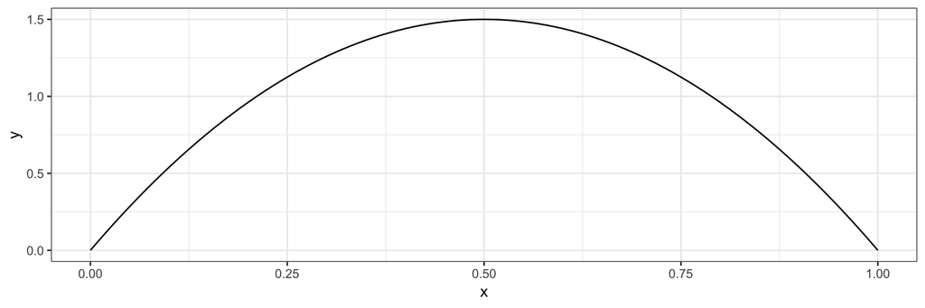

$\frac{df}{dx} = 6 - 12x = 0$ when $x = 0.5$ and the second derivative is negative, so the maximum value occurs when $x = 0.5$.

2. Recall that $\E(X) = \int x f(x) \;dx$ for a continuous random variable with pdf $f$ and $\E(X) = \sum x f(x) \;dx$ for a discrete random variable with pmf $f$. (The integral or sum is over the support of the random variable.) Compute the expected value for the following random variables.
   1. $A$ is discrete with pmf $f(x) = x/10$ for $x \in \{1, 2, 3, 4\}$.
   2. $B$ is continuous with kernel $f(x) = x^2(1-x)$ on $[0, 1]$.

      Hint: first figure out what the pdf is.

```r
x <- 1:4
p <- function(x) x/10
# Expected value is sum of values times probabilities
sum(x * p(x))
```

```
## [1] 3
```

```r
k <- function(x) x^2 * (1 - x) * (x >= 0) * (x <= 1)
integrate(k, 0, 1)
```

```
## 0.08333333 with absolute error < 9.3e-16
```

```r
f <- function(x) k(x) / integrate(k, 0 , 1)$value
integrate(f, 0, 1)
```

```
## 1 with absolute error < 1.1e-14
```

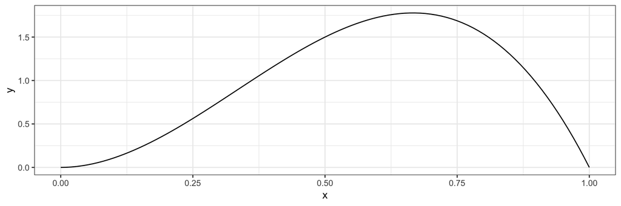

```r
gf_function(f, xlim = c(0, 1))
```

```r
# expected value
integrate(function(x) x * f(x), 0, 1)
```

```
## 0.6 with absolute error < 6.7e-15
```

3. Compute the variance and standard deviation of each of the distributions in the previous problem.
4. In Bayesian inference, we will often need to come up with a distribution that matches certain features that correspond to our knowledge or intuition about a situation. Find a normal distribution with a mean of 10 such that half of the distribution is within 3 of 10 (ie, between 7 and 13).

   Hint: use `qnorm()` to determine how many standard deviations are between 10 and 7.

```r
library(mosaic)
z <- qnorm(0.75); z
```

```
## [1] 0.6744898
```

```r
sigma <- (13 - 10) / z; sigma
```

```
## [1] 4.447807
```

```r
xpnorm(c(7, 13), mean = 10, sd = sigma)
```

```
## If X ~ N(10, 4.448), then
```

```
##  P(X <=  7) = P(Z <= -0.6745) = 0.25 P(X <= 13) = P(Z <=  0.6745) = 0.75
```

```
##  P(X >   7) = P(Z >  -0.6745) = 0.75 P(X >  13) = P(Z >   0.6745) = 0.25
```

```
## [1] 0.25 0.75
```

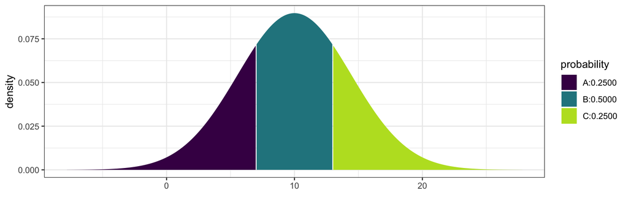

5. School children were surveyed regarding their favorite foods. Of the total sample, 20% were 1st graders, 20% were 6th graders, and 60% were 11th graders. For each grade, the following table shows the proportion of respondents that chose each of three foods as their favorite.
   1. From that information, construct a table of joint probabilities of grade and favorite food.
   2. Are grade and favorite food independent? Explain how you ascertained the answer.

      | grade | Ice cream | Fruit | French fries |
      | --- | --- | --- | --- |
      | 1st | 0.3 | 0.6 | 0.1 |
      | 6th | 0.6 | 0.3 | 0.1 |
      | 11th | 0.3 | 0.1 | 0.6 |

```r
conditional <-
  rbind(c(0.3, 0.6, 0.1), c(0.6, 0.3, 0.1), c(0.3, 0.1, 0.6))
conditional
```

```
##      [,1] [,2] [,3]
## [1,]  0.3  0.6  0.1
## [2,]  0.6  0.3  0.1
## [3,]  0.3  0.1  0.6
```

```r
marginal <-
  cbind(c(0.2, 0.2, 0.6), c(0.2, 0.2, 0.6), c(0.2, 0.2, 0.6))
marginal
```

```
##      [,1] [,2] [,3]
## [1,]  0.2  0.2  0.2
## [2,]  0.2  0.2  0.2
## [3,]  0.6  0.6  0.6
```

```r
joint <- conditional * marginal; joint
```

```
##      [,1] [,2] [,3]
## [1,] 0.06 0.12 0.02
## [2,] 0.12 0.06 0.02
## [3,] 0.18 0.06 0.36
```

```r
sum(joint)
```

```
## [1] 1
```

Grade and favorite food are not independent.

```r
conditional == marginal
```

```
##       [,1]  [,2]  [,3]
## [1,] FALSE FALSE FALSE
## [2,] FALSE FALSE FALSE
## [3,] FALSE FALSE  TRUE
```

```r
all(conditional == marginal)
```

```
## [1] FALSE
```

6. Three cards are placed in a hat. One is black on both sides, one is white on both sides, and the third is white on one side and black on the other. One card is selected at random from the three cards in the hat and placed on the table.  
   The top of the card is black.
   1. What is the probability that the bottom is also black?
   2. What notation should we use for this probability?

There are other ways to do this, but here is a way that looks like a Bayesian update of a prior using a likelihood.

```r
expand.grid(
  card = c("BB", "BW", "WW")
) %>%
  mutate(
    prior      = 1/3,   # all equally likely to be drawn
    likelihood = c(1, 0.5, 0),   # chance of see black on top
    posterior  = prior * likelihood,
    posterior  = posterior / sum(posterior)
  )
```

```
##   card     prior likelihood posterior
## 1   BB 0.3333333        1.0 0.6666667
## 2   BW 0.3333333        0.5 0.3333333
## 3   WW 0.3333333        0.0 0.0000000
```

7. The three cards from the previous problem are returned to the hat. Once again a card is pulled and placed on the table, and once again the top is black. This time a second card is drawn and placed on the table. The top side of the second card is white.
   1. What is the probability that the bottom side of the first card is black?
   2. What is the probability that the bottom side of the second card is black?
   3. What is the probability that the bottom side of both cards is black?

```r
Grid <-
  expand.grid(
    card1 = 0:2,    # number of black sides on card
    card2 = 0:2     # number of black sides on card
  ) %>%
  mutate(
    prior0     = ifelse( card1 == card2, 0, 1),
    prior      = prior0 / sum(prior0),
    likelihood = card1 / 2 * (2 - card2) / 2,
    posterior  = prior * likelihood,
    posterior  = posterior / sum(posterior)
  )
Grid %>%
  DT::datatable() %>%
  DT::formatRound(
    columns = ~ prior + likelihood + posterior,
    digits = 3)
```

|  | card1 | card2 | prior0 | prior | likelihood | posterior |
| --- | --- | --- | --- | --- | --- | --- |
| 1 | 0 | 0 | 0 | 0 | 0 | 0 |
| 2 | 1 | 0 | 1 | 0.166666666666667 | 0.5 | 0.25 |
| 3 | 2 | 0 | 1 | 0.166666666666667 | 1 | 0.5 |
| 4 | 0 | 1 | 1 | 0.166666666666667 | 0 | 0 |
| 5 | 1 | 1 | 0 | 0 | 0.25 | 0 |
| 6 | 2 | 1 | 1 | 0.166666666666667 | 0.5 | 0.25 |
| 7 | 0 | 2 | 1 | 0.166666666666667 | 0 | 0 |
| 8 | 1 | 2 | 1 | 0.166666666666667 | 0 | 0 |
| 9 | 2 | 2 | 0 | 0 | 0 | 0 |

```r
# answers
# a: card 1 has two black sides
Grid %>% filter(card1 == 2) %>% pull(posterior) %>% sum()
```

```
## [1] 0.75
```

```r
# b: second card has 1 black side
Grid %>% filter(card2 == 1) %>% pull(posterior) %>% sum()
```

```
## [1] 0.25
```

```r
# c: first card has 2 black sides, second has 1 black side
Grid %>% filter(card1 == 2, card2 == 1) %>%
  pull(posterior) %>% sum()
```

```
## [1] 0.25
```

8. Suppose there are two species of panda, A and B. Without a special blood test, it is not possible to tell them apart. But it is known that half of pandas are of each species and that 10% of births from species A are twins and 20% of births from species B are twins.
   1. If a female panda has twins, what is the probability that she is from species A?
   2. If the same panda later has another set of twins, what is the probability that she is from species A?
   3. A different panda has twins and a year later gives birth to a single panda. What is the probability that this panda is from species A?

#### Using Probability Rules

Let $A$ and $B$ be the the events that a panda is species A or B. Let $T_i$ be the event that the $i$th birth is twins.

#### part b

$$\begin{align*}
P(A \mid T_1 \cap T_2)
&= \frac{P(A \cap T_1 \cap T_2)}{P(T_1 \cap T_2)} \\
&= \frac{P(A) \cdot P(T_1 \cap T_2 \mid A)}
{P(A \cap T_1 \cap T_2) + P(B \cap T_1 \cap T_2)} \\
&= \frac{P(A) P(T_1 \cap T_2 \mid A)}
{P(A) \cdot P(T_1 \cap T_2 \mid A) + P(B) \cdot P(T_1 \cap T_2 \mid B)} \\
&= \frac{0.5 \cdot 0.1 \cdot 0.1}{0.5 \cdot 0.1 \cdot 0.1 + 0.5 \cdot 0.2 \cdot 0.2}
= 0.2
\end{align*}$$

#### part b using part a

$$\begin{align}
P(A \mid T_1 \cap T_2)
&= \frac{P(A \cap T_1 \cap T_2)}{P(T_1 \cap T_2)}
= \frac{P(A \cap T_1 \cap T_2)}{P(A \cap T_1 \cap T_2) + P(B \cap T_1 \cap T_2)}
\\
&= \frac{P(T_1) \cdot P(A \mid T_1) \cdot P(T_2 \mid A \cap T_1)}
{P(T_1) \left[ P(A \mid T_1) \cdot P(T_2 \mid A \cap T_1) +
P(B \mid T_1) \cdot P(T_2 \mid B \cap T_1) \right]} \\
&= \frac{P(A \mid T_1) \cdot P(T_2 \mid A)}
{P(A \mid T_1) \cdot P(T_2 \mid A) +
P(B \mid T_1) \cdot P(T_2 \mid B)} \\
&= \frac{\frac13 \cdot 0.1}{\frac13 \cdot 0.1 + \frac23 \cdot 0.2}
= 0.2
\end{align}$$
Notice that this says that we can use the posterior after observing the first twins as a prior for the observation of the second twins (ignoring the first twins at this point because the information from that event is now included in the new prior). This works because $P(T_2 \mid A \cap T_1) = P(T_2 \mid A)$, which follows from the assumption that $P(T_1 \cap T_2 \mid A) = P(T_1 \mid A) \cdot P(T_2 \mid A)$ (ie, that *for each species* twins in the first birth are independent of twins in the second):

$$\begin{align*}
P(T_2 \mid A \cap T_1)
&= \frac{P(T_1 \cap A \cap T_2)}
{P(A \cap T_1)}
\\
&= \frac{P(A) \cdot P(T_1 \cap T_2 \mid A)}
{P(A) \cdot P(T_1 \mid A)}
\\
&= \frac{P(A) \cdot P(T_1 \mid A) \cdot P(T_2 \mid A)}
{P(A) \cdot P(T_1 \mid A)} \\
&= P(T_2 \mid A)
\end{align*}$$
A similar statement holds with $B$ in place of $A$ by the same argument.

##### part c

Let $T_2$ be the event that the second birth is NOT twins, and the same algebra above leads to the following arithmetic:

$$\begin{align*}
\frac{0.5 \cdot 0.1 \cdot 0.9}{0.5 \cdot 0.1 \cdot 0.9 + 0.5 \cdot 0.2 \cdot 0.8}
&= 0.36
\\
\frac{\frac13 \cdot 0.9}{\frac13 \cdot 0.9 + \frac23 \cdot 0.8}
&= 0.36
\end{align*}$$

#### Grid Method style

##### part a

```r
Panda_Grid1 <-
  expand.grid(
    species = c("A", "B")
  ) %>%
  mutate(
    prior      = c(0.5, 0.5),
    likelihood = c(0.1, 0.2),
    posterior  = prior * likelihood,
    posterior  = posterior / sum(posterior)
  )
Panda_Grid1
```

```
##   species prior likelihood posterior
## 1       A   0.5        0.1 0.3333333
## 2       B   0.5        0.2 0.6666667
```

##### part b

```r
Panda_Grid2 <-
  expand.grid(
    species = c("A", "B")
  ) %>%
  mutate(
    prior      = c(0.5, 0.5),
    likelihood = c(0.1 * 0.1, 0.2 * 0.2),
    posterior  = prior * likelihood,
    posterior  = posterior / sum(posterior)
  )
Panda_Grid2
```

```
##   species prior likelihood posterior
## 1       A   0.5       0.01       0.2
## 2       B   0.5       0.04       0.8
```

```r
Panda_Grid2a <-
  Panda_Grid1 %>%
  mutate(
    prior     = posterior,
    posterior = prior * likelihood,
    posterior = posterior  / sum(posterior)
  )
Panda_Grid2a
```

```
##   species     prior likelihood posterior
## 1       A 0.3333333        0.1       0.2
## 2       B 0.6666667        0.2       0.8
```

##### part c

```r
Panda_Grid3 <-
  expand.grid(
    species = c("A", "B")
  ) %>%
  mutate(
    prior      = c(0.5, 0.5),
    likelihood = c(0.1 * 0.9, 0.2 * 0.8),
    posterior  = prior * likelihood,
    posterior  = posterior / sum(posterior)
  )
Panda_Grid3
```

```
##   species prior likelihood posterior
## 1       A   0.5       0.09      0.36
## 2       B   0.5       0.16      0.64
```

```r
Panda_Grid3a <-
  Panda_Grid1 %>%
  mutate(
    prior      = posterior,
    likelihood = c(0.9, 0.8),
    posterior  = prior * likelihood,
    posterior  = posterior  / sum(posterior)
  )
Panda_Grid3a
```

```
##   species     prior likelihood posterior
## 1       A 0.3333333        0.9      0.36
## 2       B 0.6666667        0.8      0.64
```

9. **More Pandas.** You get more interested in pandas and learn that at your favorite zoo, 70% of pandas are species A and 30% are species B. You learn that one of the pandas has twins.
   1. What is the probability that the panda is species A?
   2. The same panda has a single panda the next year. Now what is the probability that the species is A?

#### Grid Method style

##### part a

```r
Panda_Grid1 <-
  expand.grid(
    species = c("A", "B")
  ) %>%
  mutate(
    prior      = c(0.7, 0.3),
    likelihood = c(0.1, 0.2),
    posterior  = prior * likelihood,
    posterior  = posterior / sum(posterior)
  )
Panda_Grid1
```

```
##   species prior likelihood posterior
## 1       A   0.7        0.1 0.5384615
## 2       B   0.3        0.2 0.4615385
```

##### part b

```r
Panda_Grid2 <-
  expand.grid(
    species = c("A", "B")
  ) %>%
  mutate(
    prior      = c(0.7, 0.3),
    likelihood = c(0.1 * 0.9, 0.2 * 0.8),
    posterior  = prior * likelihood,
    posterior  = posterior / sum(posterior)
  )
Panda_Grid2
```

```
##   species prior likelihood posterior
## 1       A   0.7       0.09 0.5675676
## 2       B   0.3       0.16 0.4324324
```

### Some general notes about howework

1. Always show your work. If I can’t tell how you got your answer, you probably won’t get full credit.
2. For R code, follow the [style guide](https://rpruim.github.io/Kruschke-Notes/some-useful-bits-of-r.html#style-guide). It is *not optional*.
3. Discussion should not be in R comments. Use text for that.
4. Take advantage of the ability to [typeset mathematical notation in R Markdown](https://rpruim.github.io/s341/S19/from-class/MathinRmd.html).
5. Leave some margins (on all sides). And leave some space between problems.
6. Your goal should be that I can read your work easily. The more time I have to spend just figuring out what you are doing/saying, the less your work is worth. Communication is an important skill. Here’s a chance to practice.

### Probability issues

Some comments on probability based on recent homework.

1. Use good notation.
   1. If you create notation for events, random variables, etc., explain it. A good template is “Let _____ be ________”. The first blank is your notation and the second is what it means.
   2. $P(A \cap B)$, $P(A \mid B)$, and $P(B \mid A)$ mean differeng things. Be sure to use the correct one.
2. Use of the equally likely rule requires justification – how do you know the outcomes are equally likely?
3. Don’t make up probability rules. If we don’t have the rule you want to use, take a moment to show that the rule is valid. (If you can’t, perhaps it isn’t really a rule after all.)

## Chapter 5

2. Suppose we have a test with a 97% specificity and a 99% sensitivity just like in Section @ref(discrete-params). Now suppose that a random person is selected, has a first test that is positive, then is retested and has a second test that is negative.  
   Taking into account both tests, and assuming the results of the two tests are independent, what is the probability that the person has the disease?

   Hint: We can use the the posterior after the first test as a prior for the second test. Be sure to keep as many decimal digits as possible (use R and don’t round intermediate results).

   Note: In this problem we are assuming the the results of the two tests are independent, which might not be the case for some medical tests.

```r
expand.grid(
  status = c("healthy", "diseased")
  ) %>%
  mutate(
    prior1 = c(999/1000, 1/1000),
    like1  = c(0.03, 0.99),
    post1  = prior1 * like1,
    post1  = post1/ sum(post1),
    prior2 = post1,
    like2  = c(0.97, 0.01),
    post2  = prior2 * like2,
    post2  = post2/ sum(post2)
  )
```

```
##     status prior1 like1      post1     prior2 like2        post2
## 1  healthy  0.999  0.03 0.96802326 0.96802326  0.97 0.9996595692
## 2 diseased  0.001  0.99 0.03197674 0.03197674  0.01 0.0003404308
```

3. Consider again the disease and diagnostic test of the previous exercise and Section @ref(discrete-params).
   1. Suppose that a person selected at random from the population gets the test and it comes back negative. Compute the probability that the person has the disease.
   2. The person then gets re-tested, and on the second test the result is positive. Compute the probability that the person has the disease.
   3. How does the result compare with your answer in the previous exercise?

```r
expand.grid(
  status = c("healthy", "diseased")
  ) %>%
  mutate(
    prior1 = c(999/1000, 1/1000),
    like1  = c(0.97, 0.01),
    post1  = prior1 * like1,
    post1  = post1/ sum(post1),
    prior2 = post1,
    like2  = c(0.03, 0.99),
    post2  = prior2 * like2,
    post2  = post2/ sum(post2)
  )
```

```
##     status prior1 like1        post1       prior2 like2        post2
## 1  healthy  0.999  0.97 9.999897e-01 9.999897e-01  0.03 0.9996595692
## 2 diseased  0.001  0.01 1.031949e-05 1.031949e-05  0.99 0.0003404308
```

4. Modify `MyBernGrid()` so that it takes an argument specifying the probability for the HDI. Use it to create a plot showing 50% HDI for theta using a symmetric triangle prior and data consisting of 3 success and 5 failures.

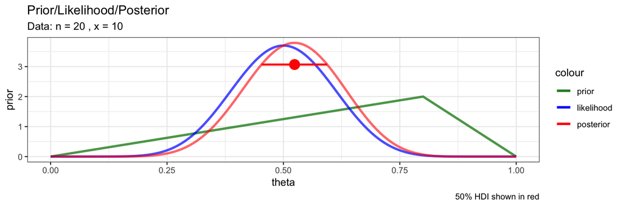

```r
MyBernGrid2 <- function(
  x, n,                   # x successes in n tries
  prior = dunif,          # function for prior
  resolution = 1000,      # number of intervals to use for grid
  prob = 0.95,            # probability for HDI
  ...) {                  # additional arguments for prior

  Grid <-
    expand.grid(
      theta = seq(0, 1, length.out = resolution + 1)
      ) %>%
    mutate( # saving only the normalized version of each
      prior = prior(theta, ...),
      prior = prior / sum(prior) * resolution,
      likelihood  = dbinom(x, n, theta),
      likelihood = likelihood / sum(likelihood) * resolution,
      posterior = prior * likelihood,
      posterior  = posterior / sum(posterior) * resolution
    )

  H <- hdi_from_grid(Grid, pars = "theta", prob = prob)

  gf_line(prior ~ theta, data = Grid, color = ~"prior",
          size = 1.15, alpha = 0.8) %>%
  gf_line(likelihood ~ theta, data = Grid, color = ~"likelihood",
          size = 1.15, alpha = 0.7) %>%
  gf_line(posterior ~ theta, data = Grid, color = ~"posterior",
          size = 1.15, alpha = 0.6) %>%
    gf_pointrangeh(
      height ~ mode + lo + hi, data = H,
      color = "red", size = 1) %>%
    gf_labs(title = "Prior/Likelihood/Posterior",
            subtitle = paste("Data: n =", n, ", x =", x),
            captions = paste0(100 * prob, "% HDI shown in red")) %>%
    gf_refine(
      scale_color_manual(
        values = c(
          "prior" = "forestgreen",
          "likelihood" = "blue",
          "posterior" = "red"),
        breaks = c("prior", "likelihood", "posterior")
        )) %>%
    print()
  invisible(Grid)   # return the Grid, but don't show it
}
library(triangle)
MyBernGrid2(10, 20, prior = dtriangle, prob = 0.5, a = 0, b = 1, c = .80)
```

5. Let’s try the grid method for a model with two parameters. Suppose we want to estimate the mean and standard deviation of the heights of 21-year-old American men or women (your choice which group). First, lets get some data.

   ```r
   library(NHANES)
   Men   <- NHANES %>% filter(Gender == "male", Age == 21)
   Women <- NHANES %>% filter(Gender == "female", Age == 21)
   ```

   **Likelihood** Our model is that heights are normally distributed with mean $\mu$ and standard deviation $\sigma$:

   **Prior.** For our prior, let’s use something informed just a little bit by what we know about people (we could do better with these priors, but that’s not our goal at the moment):
   - the mean height is somewhere between 5 and 7 feet (let’s use 150 and 200 cm which are close to that)
   - the standard deviation is positive, but no more than 20 cm (so 95% of people are within 40 cm (~ 16 inches) of average – that seems like a pretty safe bet).
   - we will use a uniform prior over these ranges (even though you probably believe that some parts of the ranges are much more credible than others).

   So our model is
   $$\begin{align*}
   \mathrm{Height} & \sim {\sf Norm}(\mu, \sigma) \\
   \mu & \sim {\sf Unif}(150, 200) \\
   \sigma & \sim {\sf Unif}(0, 20)
   \end{align*}$$

   **Grid.** Use a grid that has 200-500 values for each parameter. Fill in the ?? below to create and update your grid.

   Notes:
   - It is more numerically stable to work on the log-scale as much as possible,
   - You may normalize if you want to, but it isn’t necessary for this problem.

   ```r
   library(purrr)
   Height_Grid <-
     expand.grid(
       mu      = seq(??, ??, ?? = ??),
       sigma   = seq(??, ??, ?? = ??)
     ) %>%
     filter(sigma != 0) %>%   # remove sigma = 0
     mutate(
       prior = ??,
       logprior = ??,
       loglik =
         map2_dbl(mu, sigma,
                  ~ ?? )      # use .x for mu and .y for sigma
       logpost = logprior + loglik,
       posterior = exp(logpost)
     )
   ```

   Once you have created and updated your grid, you can visualize your posterior using a command like this (use `gf_lims()` if you want to zoom in a bit):

   ```r
   gf_tile(posterior ~ mu + sigma, data = Height_Grid) %>%
     gf_contour(posterior ~ mu+ sigma, data = Height_Grid, color = "yellow")
   ```

   Now answer the following questions.
   1. Using the picture you just created, what would you say are credible values for $\mu$ and for $\sigma$?
   2. Now use `hdi_from_grid()` to compute a 90% highest density (posterior) intervals for each parameter. Do those make sense when you compare to the picture?
   3. Create a plot showing the posterior distribution for $\mu$ and a 90% HDI for $\mu$. [Hint: how can you get a grid for the marginal distribution of $\mu$ from the grid for $\mu$ and $\sigma$?]

```r
library(purrr)
```

```r
Height_Grid <-
  expand.grid(
    mu      = seq(150, 200, by = 0.1),
    sigma   = seq(0,   20,  by = 0.1)
  ) %>%
  filter(sigma > 0) %>%         # can't have sigma be 0
  mutate(
    prior = 1,
    logprior = 0,
    loglik =
      map2_dbl(mu, sigma,
               ~ sum(dnorm(Men$Height, mean = .x, sd = .y, log = TRUE))),
    logpost = logprior + loglik,
    posterior = exp(logpost),
    posterior1 = posterior / sum(posterior, na.rm = TRUE) / (0.1 * 0.1)
  )

gf_tile(posterior ~ mu + sigma, data = Height_Grid) %>%
  gf_contour(posterior ~ mu+ sigma, data = Height_Grid, color = "yellow") %>%
  gf_lims(x = c(172, 180), y = c(7, 9))
hdi_from_grid(Height_Grid, pars = c("mu", "sigma"), prob = 0.9)
```

```
## # A tibble: 2 x 7
##   param    lo    hi  prob height mode_height  mode
##   <chr> <dbl> <dbl> <dbl>  <dbl>       <dbl> <dbl>
## 1 mu    174.   177. 0.906  0.109       0.450 176.
## 2 sigma   6.9    9  0.914  0.151       0.630   7.8
```

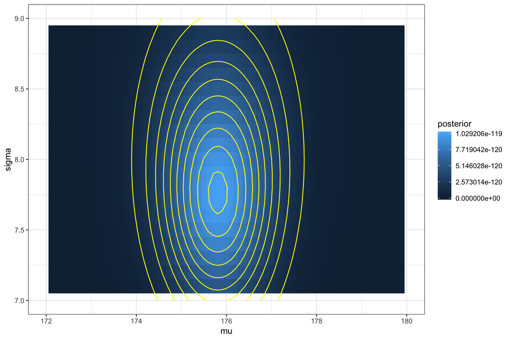

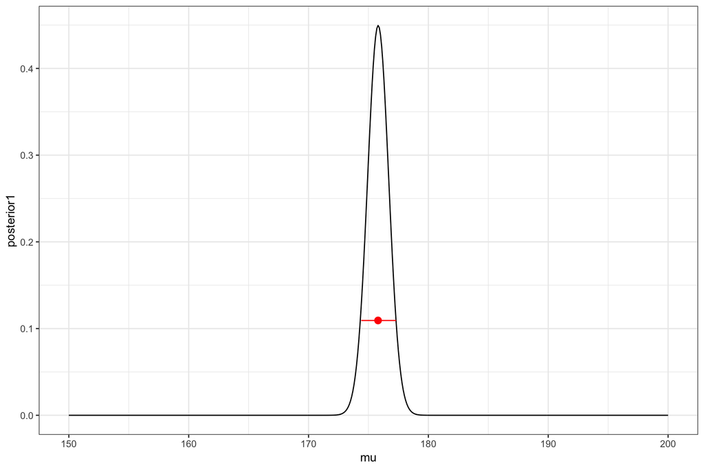

```r
Mu_Grid <-
  Height_Grid %>%
  group_by(mu) %>%
  summarise(posterior = sum(posterior1, na.rm = TRUE)) %>%
  mutate(posterior1 = posterior / sum(posterior) / 0.1)

gf_line(posterior1 ~ mu, data = Mu_Grid) %>%
  gf_pointrangeh(height ~ mode + lo + hi,
                data = hdi_from_grid(Height_Grid, pars = "mu", prob = 0.9),
                color = "red")
```

6. Redo the previous problem using a triangle prior for each parameter. You may choose where to put the peak of the triangle.

```r
library(purrr)
Height_Grid <-
  expand.grid(
    mu      = seq(150, 200, by = 0.1),
    sigma   = seq(0,   20,  by = 0.1)
  ) %>%
  filter(sigma > 0) %>%         # can't have sigma be 0
  mutate(
    prior = dtriangle(mu, 150, 200, 180) * dtriangle(sigma, 0, 20, 5),
    logprior = 0,
    loglik =
      map2_dbl(mu, sigma,
               ~ sum(dnorm(Men$Height, mean = .x, sd = .y, log = TRUE))),
    logpost = logprior + loglik,
    posterior = exp(logpost),
    posterior1 = posterior / sum(posterior, na.rm = TRUE) / (0.1 * 0.1)
  )

hdi_from_grid(Height_Grid, pars = c("mu", "sigma"), prob = 0.9)
```

```
## # A tibble: 2 x 7
##   param    lo    hi  prob height mode_height  mode
##   <chr> <dbl> <dbl> <dbl>  <dbl>       <dbl> <dbl>
## 1 mu    174.   177. 0.906  0.109       0.450 176.
## 2 sigma   6.9    9  0.914  0.151       0.630   7.8
```

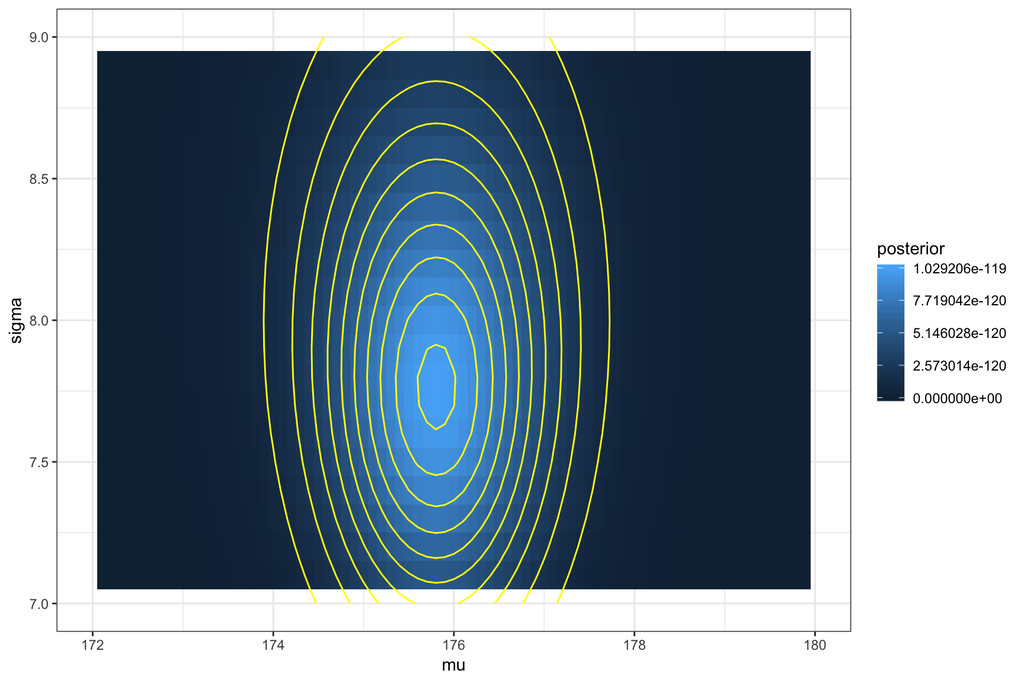

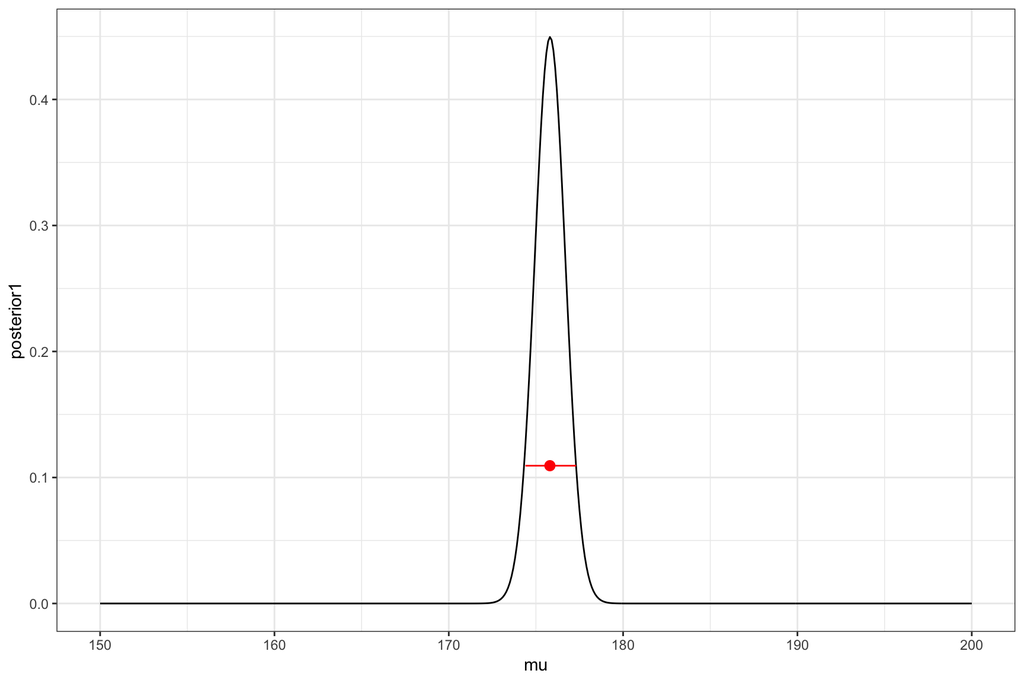

```r
gf_tile(posterior ~ mu + sigma, data = Height_Grid) %>%
  gf_contour(posterior ~ mu+ sigma, data = Height_Grid, color = "yellow") %>%
  gf_lims(x = c(172, 180), y = c(7, 9))
Mu_Grid <-
  Height_Grid %>%
  group_by(mu) %>%
  summarise(posterior = sum(posterior1, na.rm = TRUE)) %>%
  mutate(posterior1 = posterior / sum(posterior) / 0.1)

gf_line(posterior1 ~ mu, data = Mu_Grid) %>%
  gf_pointrangeh(height ~ mode + lo + hi,
                data = hdi_from_grid(Height_Grid, pars = "mu", prob = 0.9),
                color = "red")
```

7. Bob plays basketball.  
   He shoots 70% of his shots from 2-point range and makes 48% of these shots. He shoots 30% of his shots from 3-point range and makes 32% of these shots. Joe just made a shot. What is the probability that it was a 3-point shot?

   Do this problem twice. The first time, use probability rules, carefully denoting the probabilities involved. (For any number that appears, I should be able to tell from your notation where it came from.) The second time, use the “grid method”.

Here’s the grid method.

```r
expand.grid(
    shot = c(2, 3)
  ) %>%
  mutate(
    prior      = c(0.7, 0.3),
    likelihood = c(0.48, 0.32),
    posterior  = prior * likelihood,
    posterior  = posterior / sum(posterior)
  )
```

```
##   shot prior likelihood posterior
## 1    2   0.7       0.48 0.7777778
## 2    3   0.3       0.32 0.2222222
```

8. Alice has 3 hats labeled with the letters H, A, and T. In each hat are marbles of various colors.

   | Hat | White marbles | Red marbles | Yellow marbles |
   | --- | --- | --- | --- |
   | H | 4 | 10 | 6 |
   | A | 6 | 12 | 2 |
   | T | 5 | 3 | 2 |

   Alice randomly selects a hat by flipping two coins. If both are heads, she chooses hat H. If both are tails, she chooses hat T. If there is one head and one tail, she chooses hat A. Once that hat is selected, she draws out two marbles.
   1. If the two marbles are both white, what is the probability that the hat was hat A?
   2. If there is one red marble and one yellow marble, what is the probability that the hat was hat A?
   3. If the two marbles are the same color, what is the probability that the hat was hat A?

```r
expand.grid(
  hat = c("H", "A", "T")
  ) %>%
  mutate(
    prior = c(1/4, 1/2, 1/4),
    l1 = c(4/20 * 3/19, 6/20 * 5/19, 5/10 * 4/9),
    l2 = c(2 * 10/20 * 6/19, 2 * 12/20 * 2/19, 2 * 3/10 * 2/9),
    l3 = c(4/20 * 3/19 + 10/20 * 9/19  + 6/20 * 5/19,
           6/20 * 5/19 + 12/20 * 11/19 + 2/20 * 1/19,
           5/10 * 4/9  +  3/10 *  2/9  + 2/10 * 1/9),
    post1 = prior * l1 / sum(prior * l1),
    post2 = prior * l2 / sum(prior * l2),
    post3 = prior * l3 / sum(prior * l3)
    ) %>%
    filter(hat == "A")
```

```
##   hat prior         l1        l2        l3     post1 post2    post3
## 1   A   0.5 0.07894737 0.1263158 0.4315789 0.3835227  0.36 0.567256
```

2. Suppose we have a coin that we know comes from a magic-trick store, and therefore we believe that the coin is strongly biased either usually to come up heads or usually to come up tails, but we don’t know which.
   1. Express this belief as a beta prior. That is, find shape parameters that lead to a beta distribution that corresponds to this belief.
   2. Now we flip the coin 5 times and it comes up heads in 4 of the 5 flips. What is the posterior distribution?
   3. Use `quick_bern_beta()` or a similar function of your own creation to show the prior and posterior graphically.

We need a beta distribution with both shape parameters less than 1. For example:

```r
# prior probability that heads happens in <= 10% of flips
# about 1/3 <= 10%, 1/3 >= 90%, and 1/3 between 10% and 90%
pbeta(0.10 , shape1 = 0.2, shape2 = 0.2)
```

```
## [1] 0.3366898
```

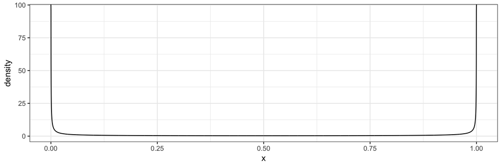

```r
gf_dist("beta", shape1 = 0.2, shape2 = 0.2)
```

The posterior in this case would be Beta(4.2, 1.2)

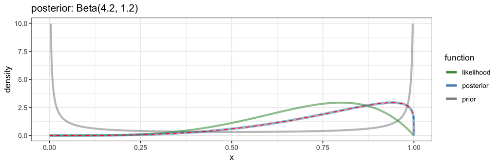

```r
library(CalvinBayes)
quick_bern_beta(x = 4, n = 5, a = 0.2, b = 0.2) %>%
  gf_dist("beta", shape1 = 4.2, shape2 = 1.2, color = "red",
          linetype = "dashed") %>%
  gf_lims(y = c(0, 10))
```